# Phase separation in hypertonic stress

## Hypothesis: NaCl causes phase separation of proteins. [Jalihal et al.](https://www.biorxiv.org/content/10.1101/748293v2.full).

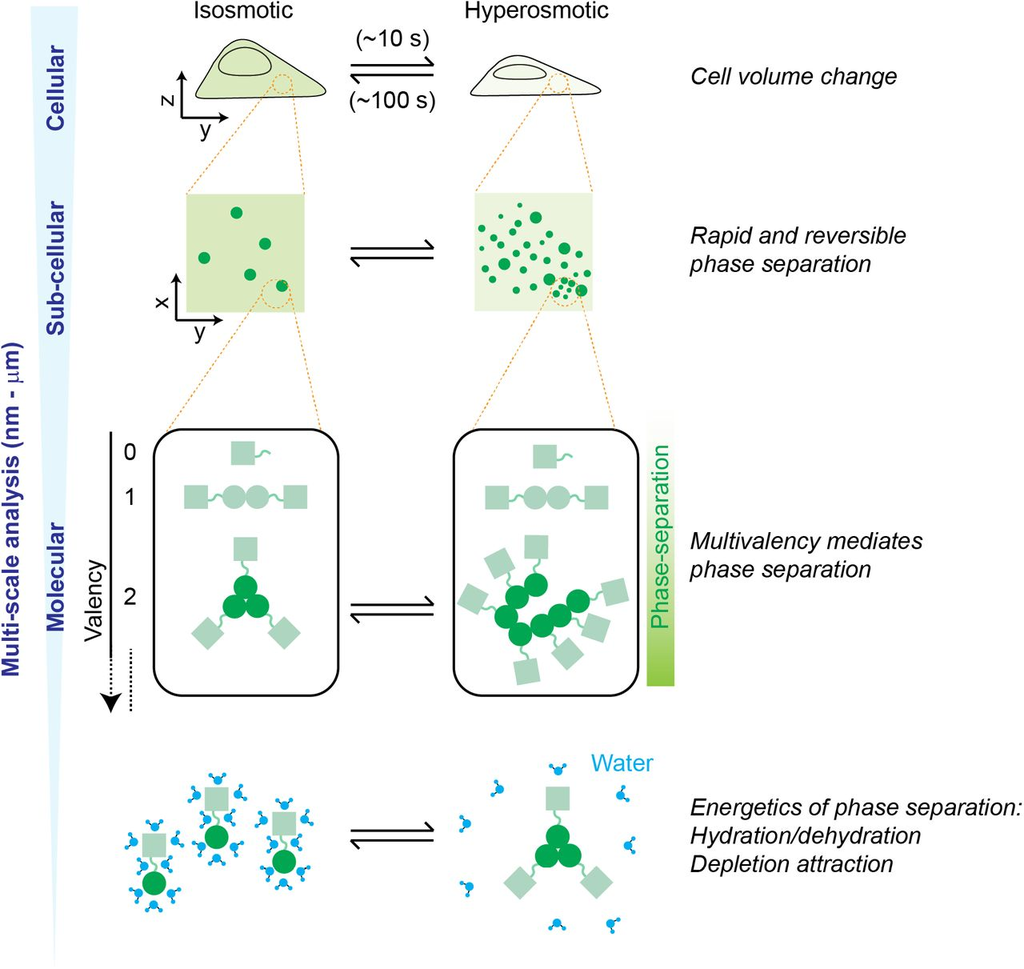

#### Figure 1: GRAPHICAL ABSTRACT

IN BRIEF Cells constantly experience osmotic variation. These external changes lead to changes in cell volume, and consequently the internal state of molecular crowding. Here, Jalihal and Pitchiaya et al. show that multimeric proteins respond rapidly to such cellular changes by undergoing rapid and reversible phase separation.

## Thoughts:

### Formaldehyde fixation fixes phase separation by crosslinking proteins in spatial proximity.

### Different proteins have different susceptibility to aggregate or phase separate.

### Changes in protein expression dynamics on a short time frame after stimulation should minimize effect of increased gene expression/translation.

### Protein activation dynamics of markers where the PTM is the epitope can respond fast.

### We observe a drop in fluorescence intensity upon step addition of NaCl.

### Can the change in fluorescence upon osmotic stress be used as a readout of valency/ predisposition of a protein to aggregate or form complexes?

### Protein markers with and without posttranslational modifications (PTM)

[interactive chart not shown]

#### Figure 2: Dynamics of protein markers after step of 300 mosmol/l NaCl.

[interactive chart not shown]

#### Figure 3:Correlation of relative protein expression between 2 and 15 min timepoints.

[interactive chart not shown]

#### Figure4: Correlation of relative protein expression between 2 and 60 min timepoints.

## Conclusions:

### Hypertonicity can cause phase separation, which can be measured through foci formation and possible by fluores. inten. reduction in Flow cytometry.

### Phase separation susceptibility might be specific for each protein.

## Perspectives:

### p38 is the master [controler of cell size](https://elifesciences.org/articles/26947)

### $\color{red}{\text{p38}}$ most affected by cell size

### p38 activation by osmotic stress not understood

### Could p38 be activated by phase separation?

### Test by repeating pulsing experiment, pulse cells for 10s, remove salt fix, do flow.

### A) p38 is not phase separating -> after removal of salt p38 still has low signal and high phosphorylation

### B) p38 is pahse separating -> after removal of salt p38 returns to normal signal and does not trigger phosphorylation

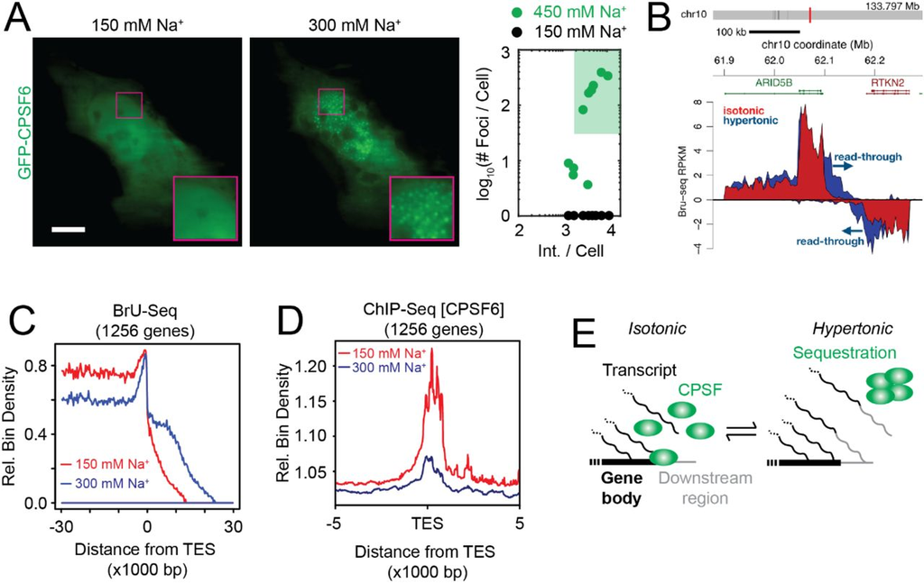

#### Figure 5: HOPS of CPSF6 is correlated with impaired transcription termination.

[interactive chart not shown]

#### Figure 6: DNA signal after step of 300 mosmol/l NaCl.